# Data Analyst Skills & Interview Questions

## Skills

- **ETL**
- **SQL, data visualization, statistical programming languages (like R and Python), machine learning, and spreadsheets.**
- **ETL: Extract, transform, load** Extract, transform, load (ETL) is the general procedure of copying data from one or more sources into a destination system which represents the data differently from the source(s) or in a different context than the source(s) Source: Wikipedia.
  - **Extract**: The first part of an ETL process involves extracting the data from the source system(s) such as
    - Relational databases, XML, JSON and flat files.
    - Also include non-relational database structures such as Information Management System (IMS) or other data structures such as Virtual Storage Access Method (VSAM) or Indexed Sequential Access Method (ISAM)
    - even formats fetched from outside sources by means such as web spidering or screen-scraping.

      *The streaming of the extracted data source and loading on the fly to the destination database is another way of performing ETL when no intermediate data storage is required.
  - **Transform**: Transform is the process that is applied to the extracted data to map it into the target form for the next storing, data warehouse, ML model, or decision-making process.
    - Most Import Part of **Transform** is **Data Cleaning**. Data comes in different forms, from different sources. It is important to clean them in a meaningful way so that it retains their insights at the same time it is ready for the **load** phase.
    - **Examples of Transform**:
      - Selecting only certain columns to load: (or selecting null columns not to load)
      - Translating coded values: (e.g., if the source system codes male as "1" and female as "2", but the warehouse codes male as "M" and female as "F")
      - Encoding free-form values: (e.g., mapping "Male" to "M")
      - Deriving a new calculated value: (e.g., sale_amount = qty * unit_price)
      - Sorting or ordering the data based on a list of columns to improve search performance.
      - Joining data from multiple sources (e.g., lookup, merge) and deduplicating the data.
      - Aggregating (for example, rollup — summarizing multiple rows of data — total sales for each store, and for each region, etc.) and so on ...

## Role of a Data Analyst

- Main Task is **ETL**

Data analysts' main job is to explore the insights of data to support decisions. In doing so, a data analyst can perform his/her duties in the main 4 fields-

- Descriptive Analysis
  - Main aim of descriptive analysis is to answer what happened in a rough overview from the data
  - Tasks involved: statistics such as count, quantity, mean, mode, standard deviations (descriptive statistics)
- Diagnostics Analysis
  - In the descriptive analysis we try to find **what happended**, and in the diagnostic analysis we try to find the reason, try to answer **why happened.**
- Predictive Analysis
  - In descriptive and diagnostics analysis we already know what happened and why did it happen. In the predictive analysis, we might look for a past pattern that could tell us about something future trends. Predictive analysis answers **what might happen in the future.**
- Prescriptive Analysis
  - This step uses all the knowledge gained in the first three steps to make well-informed decisions for the future.

## NoSQL DataBase

### What is NoSQL database?

NoSQL is a non-relational DBMS, that does not require a fixed schema, avoids joins, and is easy to scale. The purpose of using a NoSQL database is for distributed data stores with humongous data storage needs. NoSQL is used for Big data and real-time web apps. For example, companies like Twitter, Facebook, Google collect terabytes of user data every single day.

### What is NoSQL?

When people use the term “NoSQL database”, they typically use it to refer to any non-relational database. Some say the term “NoSQL” stands for “non SQL” while others say it stands for “not only SQL.” Either way, most agree that NoSQL databases are databases that store data in a format other than relational tables. If you want to find out more about NoSQL databases, our programming experts are always eager to share their knowledge with you.

Key-value stores

Column-oriented databases

Document databases

Graph databases

Multi-Model Databases

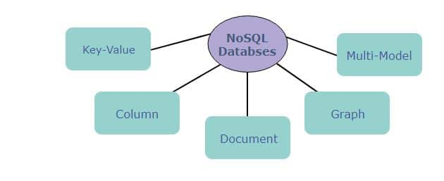

MongoDB, CouchDB, CouchBase, Cassandra, HBase, Redis, Riak, Neo4J are the popular **NoSQL databases** examples.

MongoDB, CouchDB, CouchBase , Amazon SimpleDB, Riak, Lotus Notes are **Document-oriented** NoSQL databases.

Tokyo Cabinet/Tyrant, Redis, Riak, Voldemort, Oracle BDB, Amazon SimpleDB are **Key-value stores** Databases.

Cassandra, HBase and Hypertable are **Column family stores** Databases.

Neo4J, InfoGrid, Infinite Graph, OrientDB, FlockDB are **Graph databases**.

## SQL DataBase

**Examples** Microsoft SQL Server, Oracle Database, MySQL, PostgreSQL and IBM Db2

The relational database management system (RDBMS) is the program that allows you to create, update, and administer a relational database. Structured Query Language (SQL) is the most common language for reading, creating, updating and deleting data. Relational databases are very reliable. They are compliant with ACID (Atomicity, Consistency, Isolation, Durability), which is a standard set of properties for reliable database transactions. Relational databases work well with structured data. Organizations that have a lot of unstructured or semi-structured data should not be considering a relational database.

**Both relational and non-relational databases are better for different things. SQL, for example, would be better suited for an application that requires extremely complex, intensive queries between different databases. For creating an online checkout system, for example, SQL would be an ideal choice.**

**On the other hand, non-relational databases like NoSQL are typically better for applications that require horizontal scaling and more flexible architecture, such as big data analytics and real-time web applications.**

### What is a data lake?

**Properties of SQL Database: ACID (Atomicity, Consistency, Isolation, Durability)**

A data lake is a centralized repository that allows you to store all your structured and unstructured data at any scale. You can store your data as-is, without having to first structure the data, and run different types of analytics—from dashboards and visualizations to big data processing, real-time analytics, and machine learning to guide better decisions.

### Data Lakes compared to Data Warehouses

**A data warehouse** is a database optimized to analyze relational data coming from transactional systems and line of business applications. The data structure, and schema are defined in advance to optimize for fast SQL queries, where the results are typically used for operational reporting and analysis. Data is cleaned, enriched, and transformed so it can act as the “single source of truth” that users can trust.

**A data lake** is different, because it stores relational data from line of business applications, and non-relational data from mobile apps, IoT devices, and social media. The structure of the data or schema is not defined when data is captured. This means you can store all of your data without careful design or the need to know what questions you might need answers for in the future. Different types of analytics on your data like SQL queries, big data analytics, full text search, real-time analytics, and machine learning can be used to uncover insights.

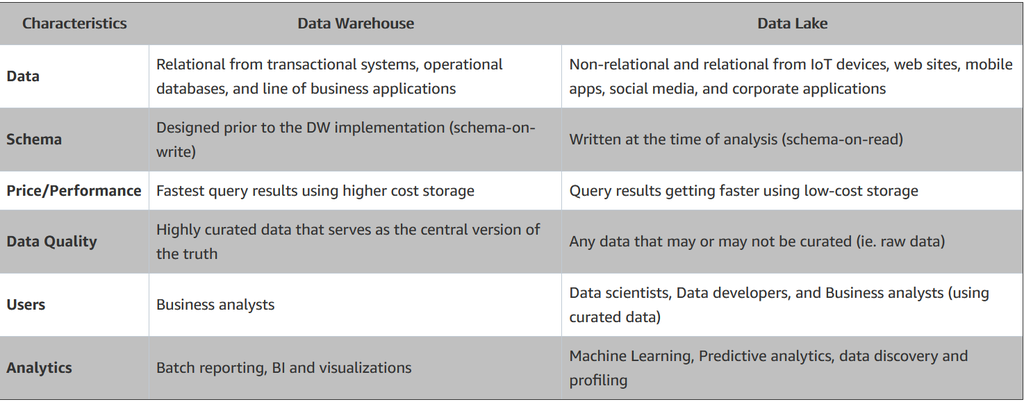

## What is qualitative data?

Qualitative data is non-statistical and is typically unstructured or semi-structured. This data isn’t necessarily measured using hard numbers used to develop graphs and charts. Instead, it is categorized based on properties, attributes, labels, and other identifiers.

**Qualitative data can be used to ask the question “why.”** It is investigative and is often open-ended until further research is conducted. Generating this data from qualitative research is used for theorizations, interpretations, developing hypotheses, and initial understandings.

- Qualitative data can be generated through:
  - Texts and documents
  - Audio and video recordings
  - Interview transcripts and focus groups
  - Observations and notes

### Examples:

- Diary accounts
- Documents
- Case studies
- Photographs
- Audio recordings
- Video recordings
- Transcriptions
- Descriptions

## What is quantitative data?

Contrary to qualitative data, quantitative data is statistical and is typically structured in nature – meaning it is more rigid and defined. This data type is measured using numbers and values, making it a more suitable candidate for data analysis.

Whereas qualitative is open for exploration, quantitative data is much more concise and close-ended. It can be used to ask the questions “how much” or “how many,” followed by conclusive information.

### Examples

- Revenue in dollars.
- Weight in kilograms.
- Age in months or years.
- Length in centimeters.
- Distance in kilometers.
- Height in feet or inches.
- Number of weeks in a year.

## Structured vs Unstructured Data

**Structured data** is highly-organized and formatted so that it's easily searchable in relational databases.

- Data may be human- or machine-generated, as long as the data is created within an RDBMS structure. This format is eminently searchable, both with human-generated queries and via algorithms using types of data and field names, such as alphabetical or numeric, currency, or date.

**Unstructured data** has no predefined format or organization, making it much more difficult to collect, process, and analyze.

- Text files: Word processing, spreadsheets, presentations, emails, logs.
- Email: Email has some internal structure thanks to its metadata, and we sometimes refer to it as semi-structured. However, its message field is unstructured and traditional analytics tools cannot parse it.
- Social Media: Data from Facebook, Twitter, LinkedIn.
- Website: YouTube, Instagram, photo sharing sites.
- Mobile data: Text messages, locations.
- Communications: Chat, IM, phone recordings, collaboration software.
- Media: MP3, digital photos, audio and video files.
- Business applications: MS Office documents, productivity applications.

**Typical machine-generated unstructured data includes:**

- Satellite imagery: Weather data, landforms, military movements.
- Scientific data: Oil and gas exploration, space exploration, seismic imagery, atmospheric data.
- Digital surveillance: Surveillance photos and video.
- Sensor data: Traffic, weather, oceanographic sensors.

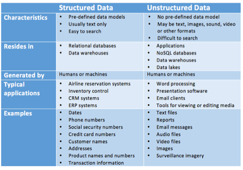